# Nonlinearity with kernel methods

# Non-linear classification toy example

#### Run the complete code chunks below, read the comments

#### Experiment with changing the data generation process and re-running them all in the same order

## 2d non-linear classification data

```r
set.seed(1) # optional: delete this line
# sample size
n <- 500
# function with zero set that
# defines the perfect (Bayes) decision boundary
true_boundary_function <- function(x1, x2) {
  # experiment with changing this
  #(x1^2 + x2^2 - 1)^3 - x1^2*x2^3
  abs(x1*x2) - x1
}
train <- data.frame(
  # change the distribution
  # or scale as needed
  x1 = 1.5*(1 - 2*runif(n)),
  x2 = 1.5*(1 - 2*runif(n))
) %>%
  mutate(
    # labels if classes were perfectly separated
    separable = true_boundary_function(x1,x2) > 0,
    # labels if classes are "noisy"
    y = factor(rbinom(n, 1, 9/10 - (8/10) * as.numeric(separable)))
  )
```

### Plot of training data

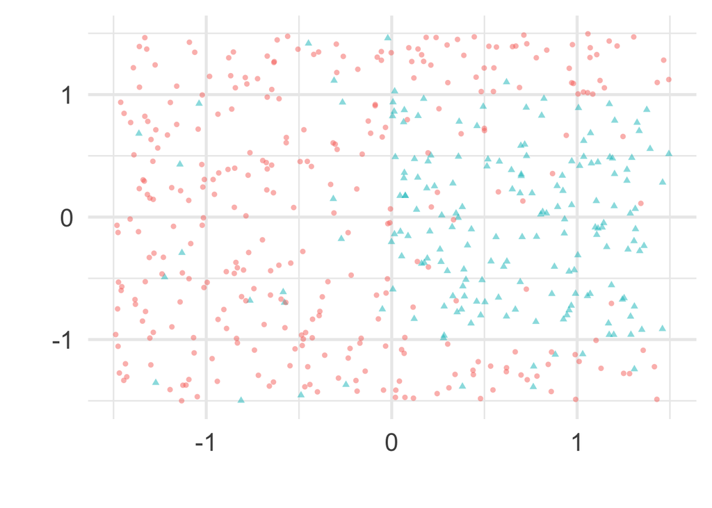

```r
train_plot <-
  ggplot(train, aes(x1, x2)) +
  geom_point(aes(shape = y, color = y),
             alpha = .5, show.legend = FALSE) +
  xlab("") + ylab("")

train_plot
```

### Plot of Bayes decision boundary

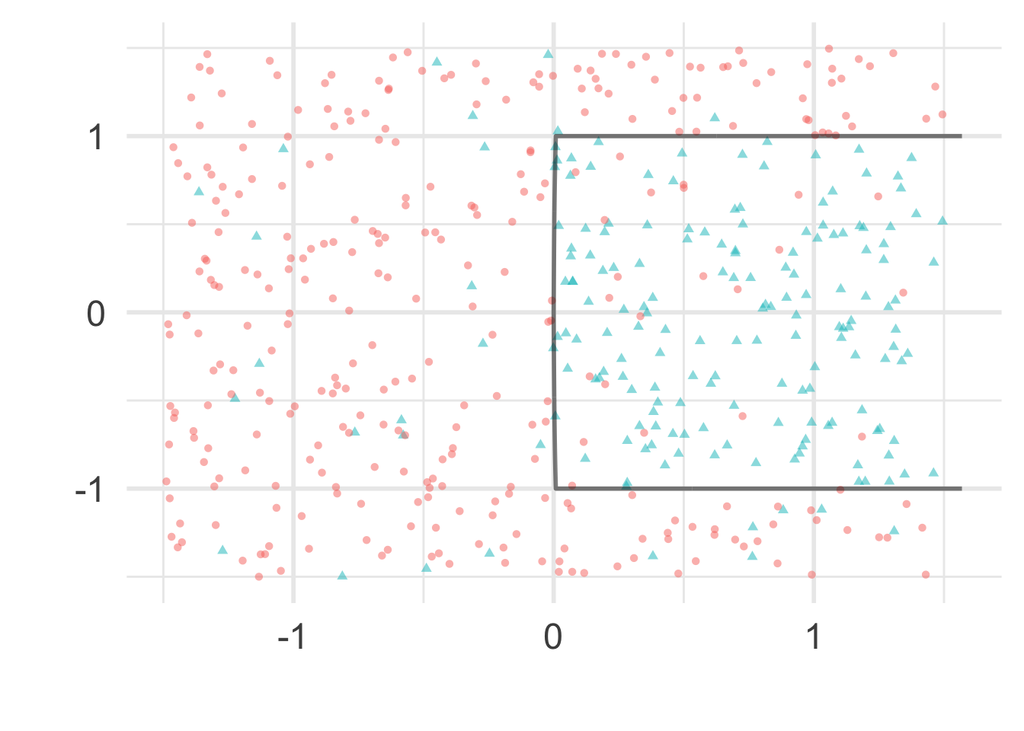

```r
decision_surface <-
  data_grid(train,
          x1 = seq_range(x1, 300, expand = .05),
          x2 = seq_range(x2, 300, expand = .05)) %>%
  mutate(z = true_boundary_function(x1, x2))

boundary_plot <-
  train_plot +
  geom_contour(
    data = decision_surface,
    aes(x1, x2, z=z),
    bins = 2,
    size = 1,
    color = "black",
    alpha = .5)

boundary_plot
```

### How well does linear classification do?

Also try changing the formula to fit a logistic regression model with non-linear transformations of the predictors

```r
# Fit model
logit_model <-
  glm(y ~ x1 + x2, family = "binomial", data = train)
# try formula + poly(x1,2) * poly(x2,2)

# Generate decision boundary
logit_surface <- logit_model %>%
   augment(type.predict = "response",
              newdata = decision_surface)
```

Plot of decision boundary of logistic model

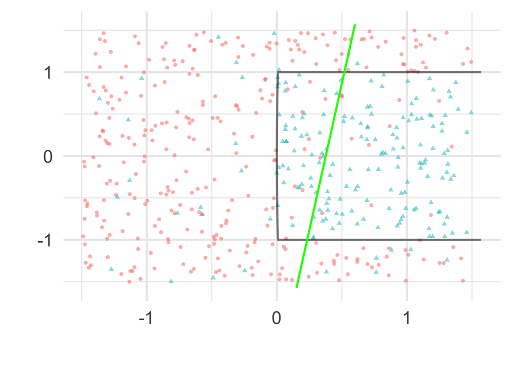

```r
boundary_plot +
  geom_contour(
    data = logit_surface,
    aes(x1, x2, z = .fitted),
    size = 1,
    color = "green",
    bins = 2)
```

# Kernel SVM

#### Use the `ksvm` function from the `kernlab` package to fit a non-linear classification models and plot them (install the package if you have not already)

#### Try different kinds of kernels

#### Experiment with cost/complexity parameters

#### Optional: change the decision boundary function, noise level, sample size, etc, in the training data

```r
k_fit <- ksvm(y ~ x2 + x1,
                  kernel = polydot(degree = 2),
                  C = 20,
                  data = train)
k_fit
```

```
## Support Vector Machine object of class "ksvm"
##
## SV type: C-svc  (classification)
##  parameter : cost C = 20
##
## Polynomial kernel function.
##  Hyperparameters : degree =  2  scale =  1  offset =  1
##
## Number of Support Vectors : 200
##
## Objective Function Value : -3946.075
## Training error : 0.14
```

#### Plot decision regions, compare to original data. What’s different?

#### Use the `nSV()` and `alphaindex()` functions to find the number of support vectors and their indexes in the training data. What proportion of the training data is used by the classifier?

# 1-d smooth regression example

#### Generate a one-dimensional example with a non-linear relationship

#### Experiment with changing `f`, `n`, `s2`, and `noise_sd`

The `beta` distribution is closer to uniform if `s2` is closer to 1, so increasing `s2` creates a region of the predictor space that has relatively less training data

```r
# change this function
f <- function(x) sin(4*pi*x)
n <- 400
s1 <- 1
s2 <- 3
noise_sd <- .4
train1d <-
  data.frame(
    x = rbeta(n, s1, s2)
    ) %>%
  mutate(y = f(x) + rnorm(n, sd = noise_sd))

# make sure this is the same as above
test1d_ID <-
  data.frame(
    x = rbeta(n, s1, s2)
    ) %>%
  mutate(y = f(x) + rnorm(n, sd = noise_sd))

# make this slightly different from above to experiment with OOD
test1d_OOD <-
  data.frame(
    x = rbeta(n, s1, s2/2) # more data with larger x values
    ) %>%
  # slightly different CEF
  mutate(y = f(x) + .1*cos(4*pi*x) + rnorm(n, sd = noise_sd))

# grid for plotting predictions
train1d_grid <-
  data_grid(train1d,
          x = seq_range(c(.05, .95), 2000, expand = .05))
```

#### Read `?geom_smooth` and change the `span` manually for a better fit

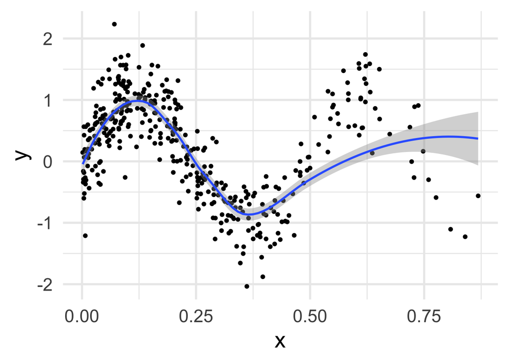

```r
# plot data and loess curve
ggplot(train1d, aes(x, y)) +
  geom_point() +
  geom_smooth()
```

### Linear regression with a polynomial transform of x

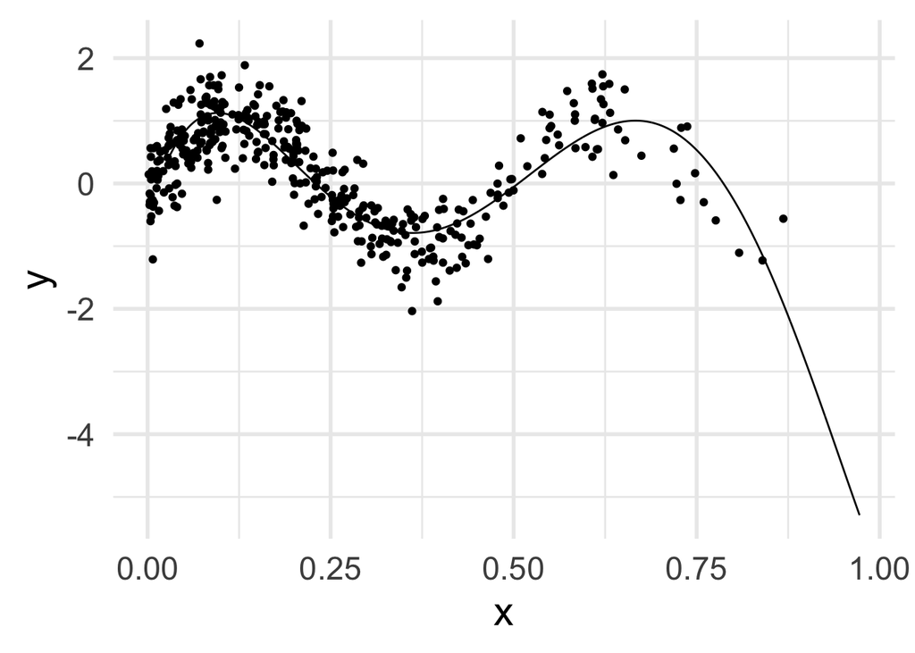

```r
model_lm <- lm(y ~ poly(x, 5), data = train1d)

augment(model_lm,
        newdata = train1d_grid) %>%
  ggplot(aes(x, y)) +
  geom_point(data = train1d) +
  geom_line(aes(y = .fitted)) #+ ylim(c(-3,3))
```

### Kernel regression

Use the `ksvm` function to fit non-linear kernel regression models and plot the predictions on `train1d_grid`

```r
k_1fit <- ksvm(y ~ x,
     #kernel = rbfdot(sigma = 10),
     kernel = polydot(degree = 2),
     data = train1d)
k_1fit
```

```
## Support Vector Machine object of class "ksvm"
##
## SV type: eps-svr  (regression)
##  parameter : epsilon = 0.1  cost C = 1
##
## Polynomial kernel function.
##  Hyperparameters : degree =  2  scale =  1  offset =  1
##
## Number of Support Vectors : 365
##
## Objective Function Value : -258.3988
## Training error : 0.833803
```

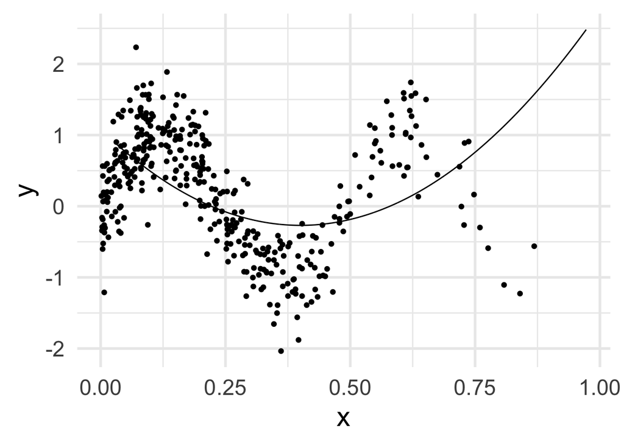

```r
svm_predictions <- train1d_grid %>%
      mutate(.fitted = predict(k_1fit, newdata = train1d_grid))

train1d %>%
  ggplot(aes(x, y)) +
  geom_point(data = train1d) +
  geom_line(
    data = svm_predictions,
    aes(y = .fitted)) #+ylim(c(-2,2))
```

### Comparisons

```r
fits <- list(
augment(model_lm,
        newdata = test1d_ID) %>%
  mutate(generalization = "ID", model = "lm"),

test1d_ID %>%
      mutate(.fitted = predict(k_1fit, newdata = test1d_ID),
             generalization = "ID", model = "ksvm"),

augment(model_lm,
        newdata = test1d_OOD) %>%
  mutate(generalization = "OOD", model = "lm"),

test1d_OOD %>%
      mutate(.fitted = predict(k_1fit, newdata = test1d_OOD),
             generalization = "OOD", model = "ksvm"))

map_dfr(fits, rbind) %>%
  mutate(resid = y - .fitted) %>%
  group_by(generalization, model) %>%
  summarize(MSE = mean(resid^2), .groups = "keep")
```

```
## # A tibble: 4 x 3
## # Groups:   generalization, model [4]
##   generalization model   MSE
##   <chr>          <chr> <dbl>
## 1 ID             ksvm  0.559
## 2 ID             lm    0.232
## 3 OOD            ksvm  0.939
## 4 OOD            lm    0.940
```

#### What happens to the local accuracy for larger values of x if `s2` is increased? Why?

#### What happens as `sd` is increased? Or if `n` is decreased? How is this different from the previous question?

#### What happens if you increase `sigma` in `rbfdot`?

#### How would ID generalization vs OOD vary depending on the above trade-offs? Consider OOD for values of x slightly both outside the left and right range of the training data

## Optional extra practice: gapminder

Fit a kernel regression model on `gapminder` data, plot the predictions, calculate the MSE

Calculate the MSE using a different year as test data to check OOD performance